# Probabilistic Modeling

Introduction to Bayesian Statistics

| Diogo Melo Lewis-Sigler Institute of Integrative Genomics damelo@princeton.edu |
| --- |

## Intro

### Maximum Likelihood estimation

- Up to this point we have been using the Maximum Likelihood principle
- ML has many advantages:
  - General
  - (mostly) Automatic
  - Good theoretical justification
  - Good performance

### The Maximum Likelihood way

Given some data…

Define an observational model:

Maximize the likelihood over the parameter space:

Any further inference uses this ML estimator

### Log Likelihood surface

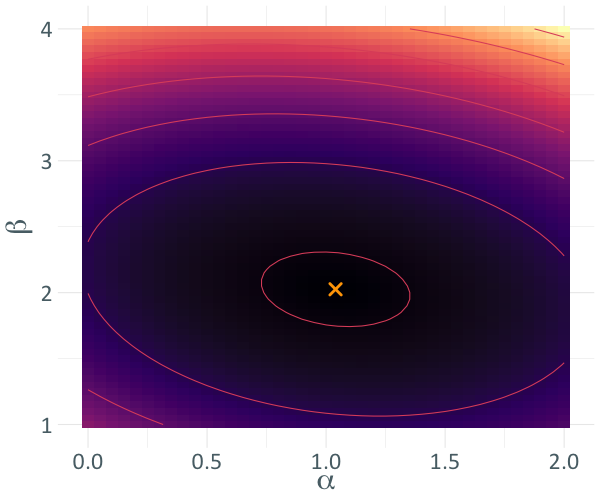

## Bayes

## rev thomas bayes (1701 – 1761)

[figure not shown]

## Product rule (or Bayes Theorem)

### What is Bayesian Statistics?

We can think of Bayesian Statistics as an extension of ML

- ML: What is the parameter value that maximizes the probability of having generated the data:
- Bayes: What is the probability distribution of parameter values given the data:

### Probability Theory: The Logic of Science (2003)

[figure not shown]

By Edwin Thompson Jaynes (1922 – 1998)

### Statistical rethinking (2020)

[figure not shown]

By Richard McElreath (youtube.com/@rmcelreath)

### Prior Likelihood Posterior

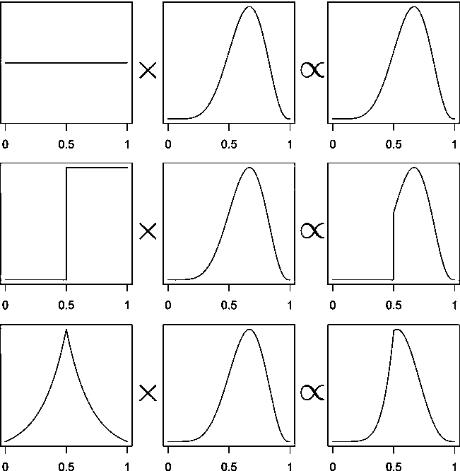

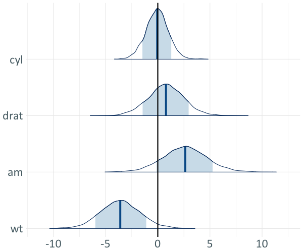

### nuisance variables

We can add additional variables that help to define the model but are not present in the posterior

## Using the posterior

### Posterior estimators

Bayesian equivalent to MLE is the **M**aximum **A** **P**osteriori (MAP):

The posterior mean is more common:

(Posterior median is also used occasionally.)

### Posterior approximations

- For a small number of models we can write the posterior distribution directly (really small, don't bother).
- For most models, we use posterior samples to approximate the posterior.

### Posterior sample histogram

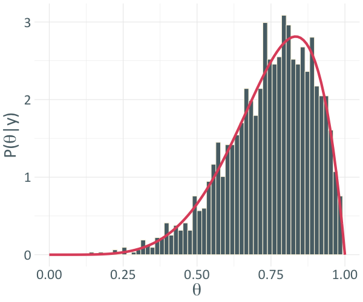

### Posterior derived QUANTITIES

This sample can be used to calculate any quantity of interest

For example, the posterior mean is just:

### Other quantities

- Any other functions of the parameters can be estimated from the samples
- A common use is to calculate contrast between categorical levels, estimating the difference between groups

### Categorial predictors

We can also use categorical predictors to estimate per-group averages.

### Per clade milk content

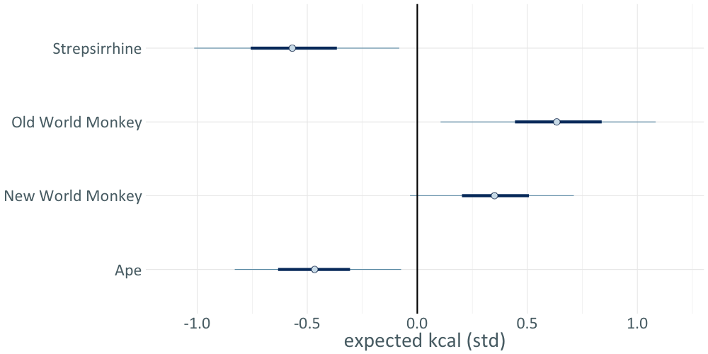

### contrasts

To compare coefficient estimates we must look at the distribution of differences

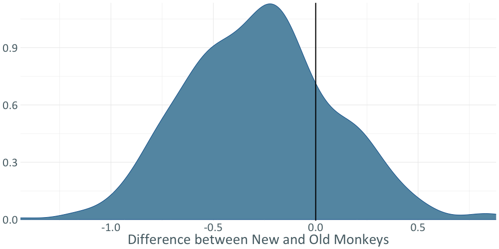

## Building a model

### My first bayesian regression model

Given the matched pairs:

Define a likelihood:

And a set of priors on the parameters:

### How do we choose the priors?

- Agnostic choices
  - Laplace and the Principle of indifference
  - “Uninformative” priors
- Maximum entropy priors
  - priors that encode the least amount of information given constraints
- Jeffreys priors
  - invariant under a change of coordinates
- Hard constraints
  - restricted domains (e.g. variance must be positive)

### Good prior choices

- Use domain expertise!
  - Knowledge of scale (height weight example)
  - Experimental design (more in the hierarchical models class)
  - Using simulations to understand the implications of priors

### priors can be used to encode scale information

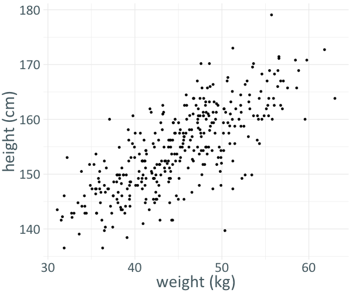

Adapted from McElreath (2020).

### Wide prior

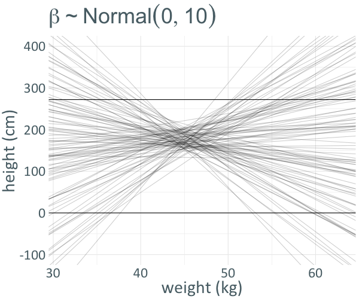

This is sometimes called a non-informative prior

### sensible priors

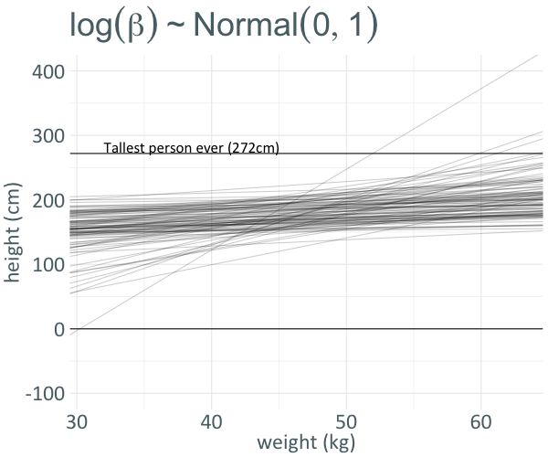

This prior is informative, but in a good way!

### Our model for the height data

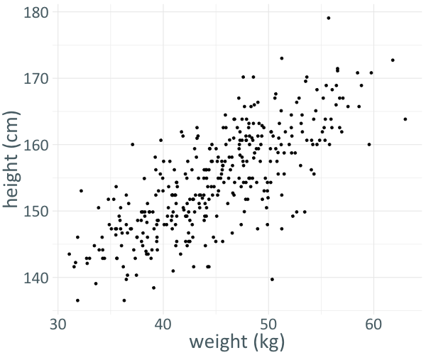

### Posterior samples

```python
> samples
# A tibble: 2,000 × 3
           a         b     sigma
   <dbl[1d]> <dbl[1d]> <dbl[1d]>
 1      115.     0.889      4.78
 2      109.     1.02       5.30
 3      112.     0.928      5.07
 4      111.     0.949      5.30
 5      111.     0.955      5.04
 6      115.     0.872      5.19
 7      109.     1.01       5.13
 8      117.     0.844      5.00
 9      115.     0.882      4.94
10      112.     0.939      4.95
# … with 1,990 more rows
```

### Posterior mean estimates

```
> colMeans(samples)
          a           b       sigma
112.9296580   0.9253803   5.0453651
```

### Model fit

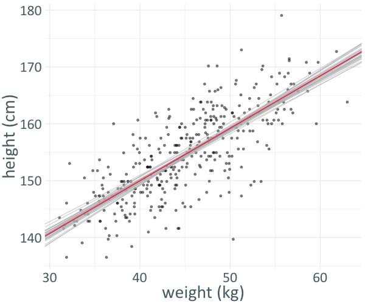

### Posterior parameter distribution

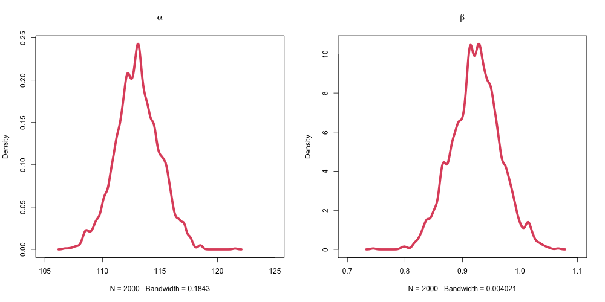

## References

JAYNES, E. T. **Probability theory: The logic of science**. [s.l.] Cambridge university press, 2003. [🔎](http://www.bing.com/search?q=Probability%20theory%3A%20The%20logic%20of%20science%20Jaynes%2C%202003)

MCELREATH, R. **Statistical rethinking: A Bayesian course with examples in R and Stan**. [s.l.] Chapman and Hall/CRC, 2020. [🔎](http://www.bing.com/search?q=Statistical%20rethinking%3A%20A%20Bayesian%20course%20with%20examples%20in%20R%20and%20Stan%20McElreath%2C%202020)